# TP Cartes de contrôle

Erivan INAN, M2 ISDS, 2025

```
                                              TP CARTES DE CONTRÔLE
```

**————————————————————– IMPORTATION DES LIBRAIRIES NÉCESSAIRES ————————————————————-**

```r
# bibliothèques nécessaires
library(ggplot2)
library(qcc)
```

**————————————————————————————— EXERCICE 1 ————————————————————————————–**

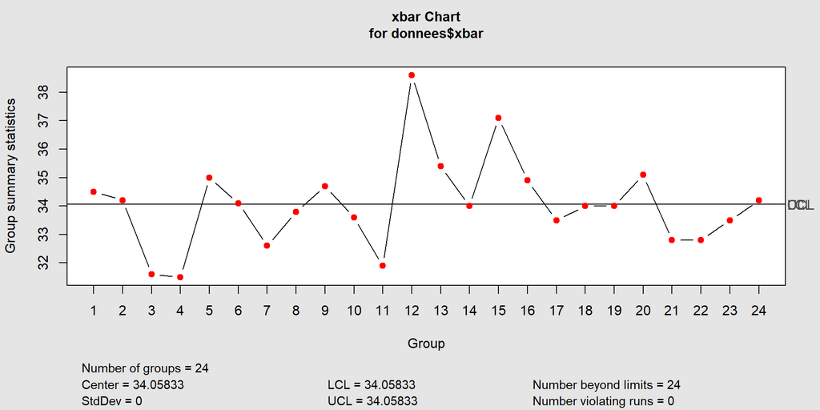

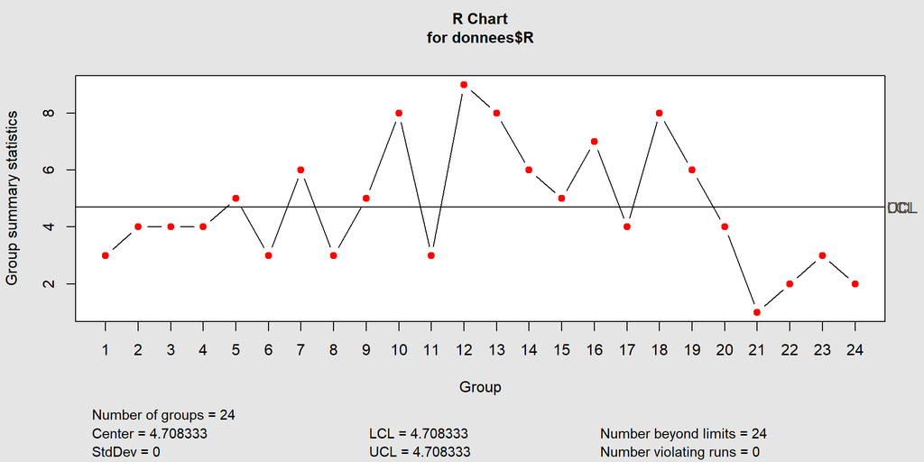

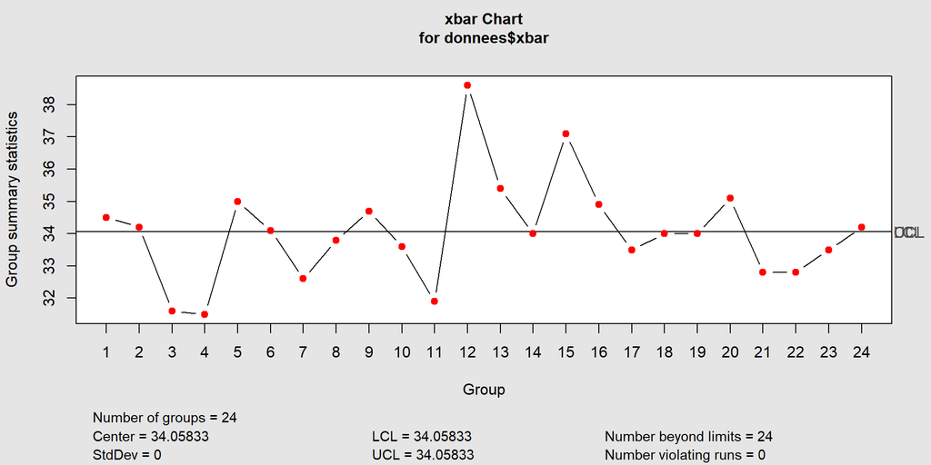

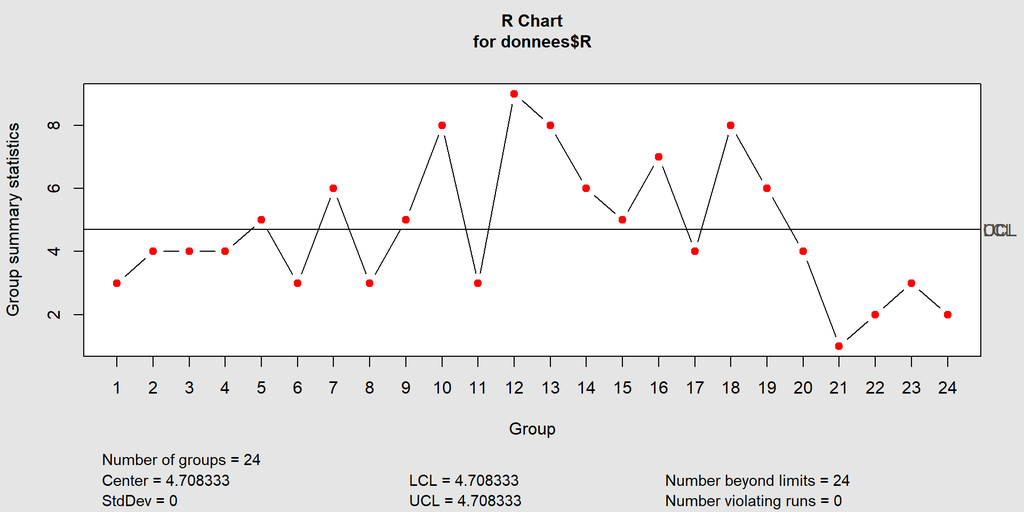

```r
# data figure 1
donnees <- data.frame(
  sample = 1:24,
  xbar = c(34.5, 34.2, 31.6, 31.5, 35.0, 34.1, 32.6, 33.8, 34.7, 33.6, 31.9, 38.6,
           35.4, 34.0, 37.1, 34.9, 33.5, 34.0, 34.0, 35.1, 32.8, 32.8, 33.5, 34.2),
  R = c(3, 4, 4, 4, 5, 3, 6, 3, 5, 8, 3, 9,
        8, 6, 5, 7, 4, 8, 6, 4, 1, 2, 3, 2)
)

# def de la taille des sous-groupes, ici 4
taille_sous_groupe <- 4

# cartes de contrôle
carte_xbar <- qcc(donnees$xbar, type = "xbar", sizes = taille_sous_groupe)  # carte des moyennes
carte_r <- qcc(donnees$R, type = "R", sizes = taille_sous_groupe)           # carte des étendues

# Affichage des cartes
plot(carte_xbar)
plot(carte_r)
```

**————————————————————————————— EXERCICE 4 ————————————————————————————–**

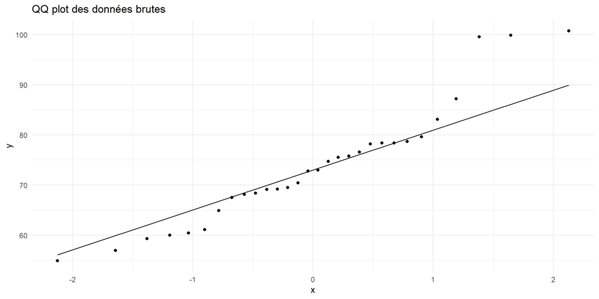

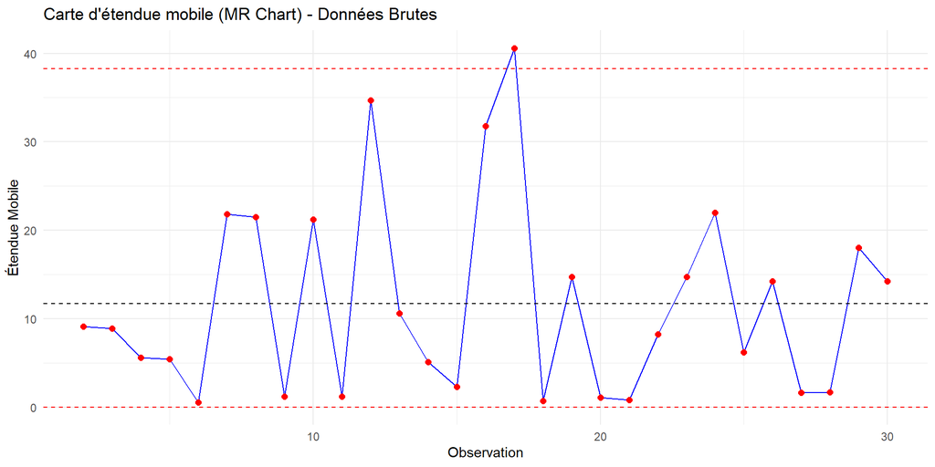

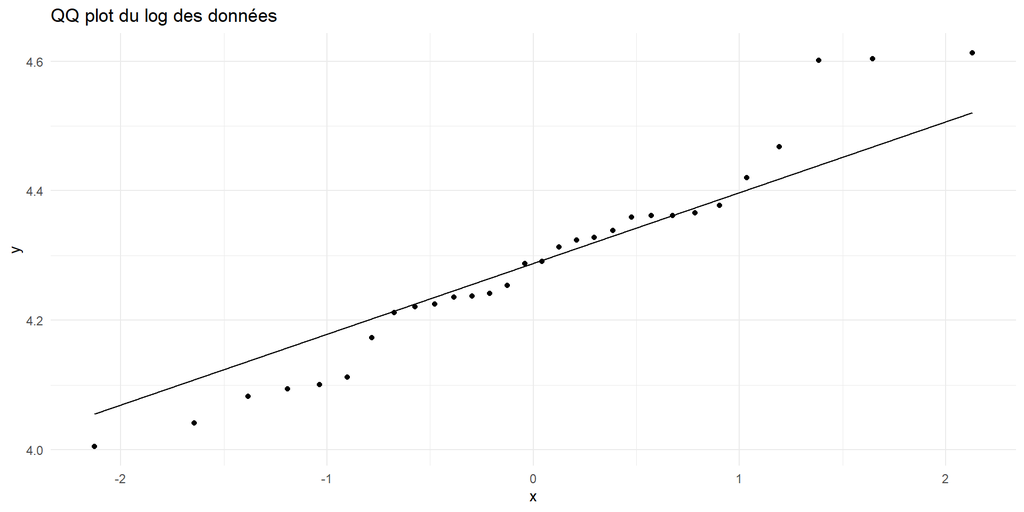

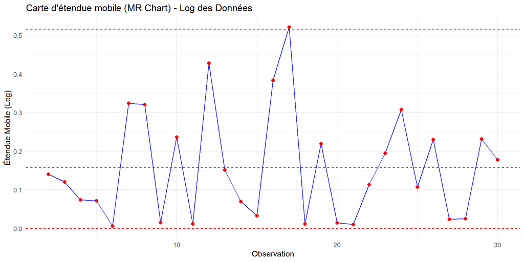

```r
# data figure 4
concentration <- c(60.4, 69.5, 78.4, 72.8, 78.2, 78.7, 56.9, 78.4, 79.6, 100.8,
                   99.6, 64.9, 75.5, 70.4, 68.1, 99.9, 59.3, 60.0, 74.7, 75.8,
                   76.6, 68.4, 83.1, 61.1, 54.9, 69.1, 67.5, 69.2, 87.2, 73.0)

# étude de la normalité avec un QQ plot
ggplot(data.frame(concentration), aes(sample = concentration)) +
  stat_qq() + stat_qq_line() +
  ggtitle("QQ plot des données brutes") +
  theme_minimal()

# Calcul de l'étendue mobile
etendue_mobile <- abs(diff(concentration))  # Différence absolue entre observations successives

# Calcul des limites de contrôle pour la carte d’étendue mobile
MR_bar <- mean(etendue_mobile)  # moyenne de l'étendue mobile
D4 <- 3.267  # facteur standard pour une carte MR avec n=2
D3 <- 0  # facteur standard (souvent fixé à 0)

UCL <- D4 * MR_bar  # limite supérieure de contrôle
LCL <- max(D3 * MR_bar, 0)  # limite inférieure de contrôle (ne peut pas être négative)

# carte d'étendue mobile
df <- data.frame(Observation = 2:length(concentration), MR = etendue_mobile)

ggplot(df, aes(x = Observation, y = MR)) +
  geom_line(color = "blue") +  # Ligne des valeurs
  geom_point(size = 2, color = "red") +  # Points des valeurs
  geom_hline(yintercept = MR_bar, linetype = "dashed", color = "black") +  # Moyenne
  geom_hline(yintercept = UCL, linetype = "dashed", color = "red") +  # limite supérieure
  geom_hline(yintercept = LCL, linetype = "dashed", color = "red") +  # limite inférieure
  ggtitle("Carte d'étendue mobile (MR Chart) - Données Brutes") +
  ylab("Étendue Mobile") +
  xlab("Observation") +
  theme_minimal()

# transformation logarithmique
log_concentration <- log(concentration)

# étude de la normalité avec un QQ plot (log des données)
ggplot(data.frame(log_concentration), aes(sample = log_concentration)) +
  stat_qq() + stat_qq_line() +
  ggtitle("QQ plot du log des données") +
  theme_minimal()

# calcul de l'étendue mobile pour les log(données)
etendue_mobile_log <- abs(diff(log_concentration))

# calcul des limites de contrôle pour la carte MR des log(données)
MR_bar_log <- mean(etendue_mobile_log)
UCL_log <- D4 * MR_bar_log
LCL_log <- max(D3 * MR_bar_log, 0)

# Affichage de la carte d'étendue mobile pour les log(données)
df_log <- data.frame(Observation = 2:length(log_concentration), MR = etendue_mobile_log)

ggplot(df_log, aes(x = Observation, y = MR)) +
  geom_line(color = "blue") +
  geom_point(size = 2, color = "red") +
  geom_hline(yintercept = MR_bar_log, linetype = "dashed", color = "black") +
  geom_hline(yintercept = UCL_log, linetype = "dashed", color = "red") +
  geom_hline(yintercept = LCL_log, linetype = "dashed", color = "red") +
  ggtitle("Carte d'étendue mobile (MR Chart) - Log des Données") +
  ylab("Étendue Mobile (Log)") +
  xlab("Observation") +
  theme_minimal()
```

**————————————————————————————— EXERCICE 5 ————————————————————————————–**

```r
# data figure 5
x <- c(10.07, 10.47, 9.45, 9.44, 8.99, 7.74, 10.63, 9.78, 9.37, 9.95,
       12.04, 10.93, 11.54, 9.58, 8.80, 12.94, 10.78, 11.26, 9.48, 11.28,
       12.54, 11.48, 13.26, 11.10, 10.82)

n <- length(x)  # Nombre total d'observations

# estimation de l'écart type avec la moyenne de l’étendue mobile
etendue_mobile <- abs(diff(x))
sigma_MR <- mean(etendue_mobile) / 1.128  # facteur 1.128 pour n=2

# estimation de l'écart type avec s / c4
s <- sd(x)  # Écart-type classique
c4 <- sqrt(2 / (n - 1)) * gamma(n / 2) / gamma((n - 1) / 2)  # Facteur correcteur
sigma_s_c4 <- s / c4

# estimation de l'écart type avec la médiane de l’étendue mobile
sigma_MR_mediane <- median(etendue_mobile) / 1.128  # Utilisation de la médiane au lieu de la moyenne

# estimation de l'écart type en utilisant une étendue mobile d’écart k (3 ≤ k ≤ 20)
sigma_k_list <- c()
for (k in 3:20) {
  etendue_k <- abs(x[(k+1):n] - x[1:(n-k)])  # Étendue mobile pour k
  sigma_k <- mean(etendue_k) / 1.128  # Même facteur correcteur
  sigma_k_list <- c(sigma_k_list, sigma_k)
}

# Affichage
cat("Écart type avec moyenne de l’étendue mobile :", sigma_MR, "\n")
```

```
## Écart type avec moyenne de l’étendue mobile : 1.156546
```

```r
cat("Écart type avec s/c4 :", sigma_s_c4, "\n")
```

```
## Écart type avec s/c4 : 1.35568
```

```r
cat("Écart type avec médiane de l’étendue mobile :", sigma_MR_mediane, "\n")
```

```
## Écart type avec médiane de l’étendue mobile : 0.9618794
```

```r
cat("Écart type avec moyenne des étendues mobiles d’écart k (moyenne pour k=3 à 20) :", mean(sigma_k_list), "\n")
```

```
## Écart type avec moyenne des étendues mobiles d’écart k (moyenne pour k=3 à 20) : 1.49965
```

**————————————————————————————— VISUALISATION DES DISTRIBUTIONS ET BOXPLOTS**

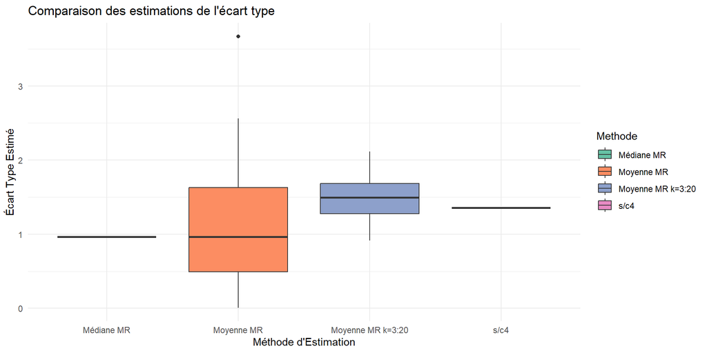

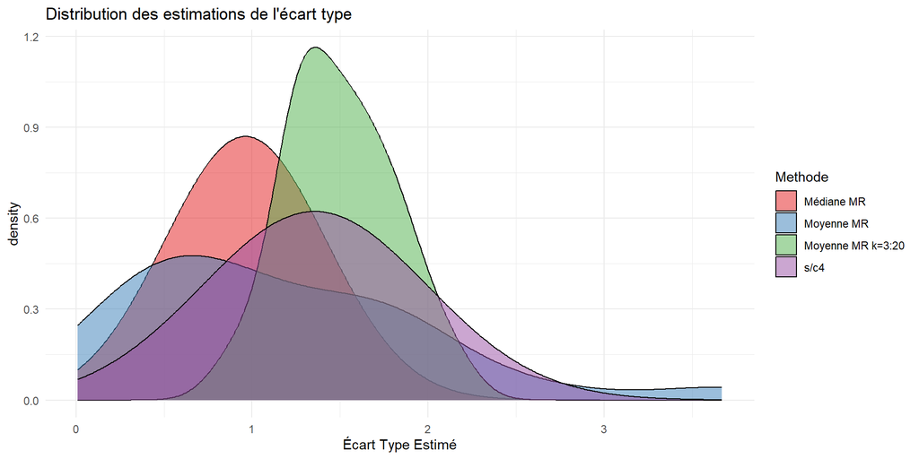

```r
# tableau avec toutes les estimations d'écart type
resultats_df <- data.frame(
  Methode = c(rep("Moyenne MR", length(etendue_mobile)),
              rep("s/c4", length(x)),
              rep("Médiane MR", length(etendue_mobile)),
              rep("Moyenne MR k=3:20", length(sigma_k_list))),
  Ecart_Type = c(etendue_mobile / 1.128,  # Normalisation par d2 pour n=2
                 rep(sigma_s_c4, length(x)),
                 rep(median(etendue_mobile) / 1.128, length(etendue_mobile)),
                 sigma_k_list)
)

# boxplots des estimations d'écart type
ggplot(resultats_df, aes(x = Methode, y = Ecart_Type, fill = Methode)) +
  geom_boxplot() +
  ggtitle("Comparaison des estimations de l'écart type") +
  ylab("Écart Type Estimé") +
  xlab("Méthode d'Estimation") +
  theme_minimal() +
  scale_fill_brewer(palette = "Set2")

# visualisation des distributions des estimations d'écart type
ggplot(resultats_df, aes(x = Ecart_Type, fill = Methode)) +
  geom_density(alpha = 0.5) +
  ggtitle("Distribution des estimations de l'écart type") +
  xlab("Écart Type Estimé") +
  theme_minimal() +
  scale_fill_brewer(palette = "Set1")
```

**————————————————————————————— COMPARAISON DES RÉSULTATS**

L’analyse des différentes méthodes d’estimation de l’écart type met en évidence des écarts notables entre les valeurs obtenues. La moyenne de l’étendue mobile donne une estimation de 1.1565, tandis que la médiane de l’étendue mobile fournit une valeur plus faible de 0.9619. De son côté, la méthode classique s/c4 donne une estimation plus élevée de 1.3557, et enfin, l’estimation basée sur la moyenne des étendues mobiles pour un écart k variant de 3 à 20 aboutit à une valeur encore plus grande de 1.4996.

Le graphique de distribution des estimations met également en évidence que la méthode basée sur la moyenne des étendues mobiles d’écart k (3 ≤ k ≤ 20) produit les valeurs les plus élevées d’écart type. Cela s’explique par le fait que cette méthode tient compte de variations à plus long terme, ce qui tend à capturer une plus grande dispersion des données. En comparaison, les autres méthodes, qui se basent sur des écarts successifs ou des correctifs statistiques, donnent des valeurs plus modérées.

En conclusion, le choix de la méthode dépend du contexte d’utilisation. Si l’on souhaite une estimation robuste et moins influencée par les valeurs extrêmes, la médiane de l’étendue mobile semble être un bon choix. Si l’objectif est d’avoir une estimation globale de la variabilité, alors la méthode s/c4 est préférable. Enfin, si l’on veut capturer les variations à long terme dans les données, l’estimation basée sur l’étendue mobile avec un écart k est la plus pertinente.

**————————————————————————————— EXERCICE 6 ————————————————————————————–**

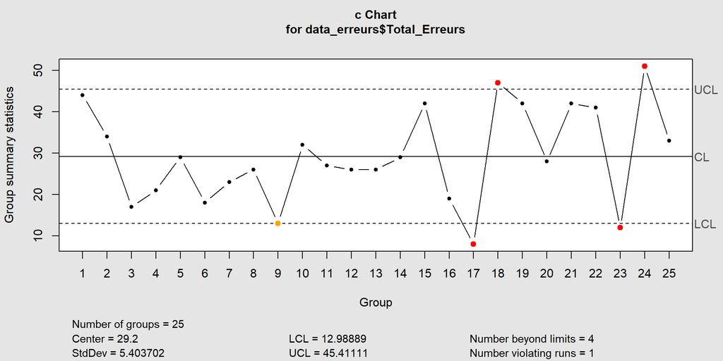

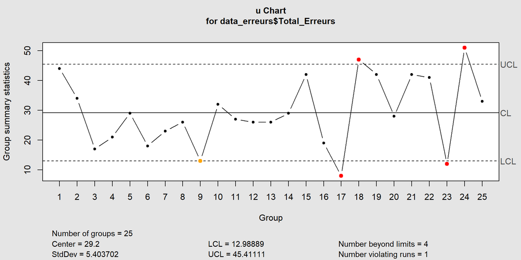

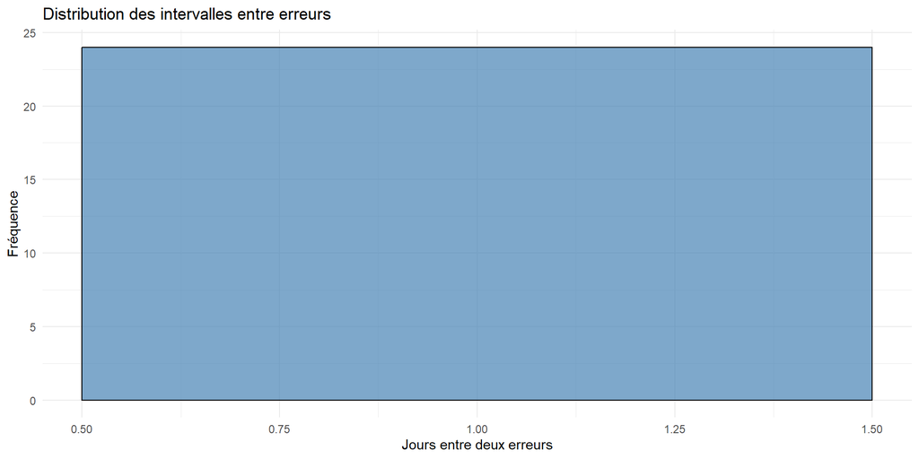

```r
# data figure 6
data_erreurs <- data.frame(
  Jour = 1:25,
  Record1 = c(8, 11, 1, 3, 3, 6, 8, 4, 1, 15, 1, 6, 7, 2, 6, 2, 1, 5, 6, 2, 7, 4, 4, 15, 2),
  Record2 = c(7, 1, 1, 2, 2, 3, 6, 10, 6, 1, 7, 7, 6, 9, 14, 9, 1, 15, 5, 7, 5, 8, 1, 2, 15),
  Record3 = c(1, 11, 8, 5, 13, 3, 3, 2, 1, 6, 13, 9, 9, 3, 7, 4, 1, 19, 19, 9, 6, 4, 4, 7, 3),
  Record4 = c(11, 2, 2, 6, 6, 1, 1, 6, 3, 2, 5, 3, 3, 8, 7, 2, 3, 2, 6, 2, 14, 20, 1, 10, 11),
  Record5 = c(17, 9, 5, 5, 5, 5, 5, 4, 2, 8, 1, 1, 1, 7, 8, 2, 2, 6, 6, 8, 10, 5, 2, 17, 2)
)

# calcul du nombre total d'erreurs par jour
data_erreurs$Total_Erreurs <- rowSums(data_erreurs[, -1])

# carte de contrôle c (nombre total d’erreurs)
carte_c <- qcc(data_erreurs$Total_Erreurs, type = "c", plot = TRUE)

# carte de contrôle u (taux d'erreurs par unité inspectée)
# Hypothèse : Chaque jour représente une unité inspectée
carte_u <- qcc(data_erreurs$Total_Erreurs, type = "u", sizes = rep(1, nrow(data_erreurs)), plot = TRUE)

# analyse de la distribution des intervalles entre erreurs
jours_erreurs <- data_erreurs$Jour[data_erreurs$Total_Erreurs > 0]  # Jours avec erreurs
temps_entre_erreurs <- diff(jours_erreurs)  # Intervalle entre erreurs successives

# Visualisation de la distribution des intervalles entre erreurs
ggplot(data.frame(Intervalle = temps_entre_erreurs), aes(x = Intervalle)) +
  geom_histogram(binwidth = 1, fill = "steelblue", color = "black", alpha = 0.7) +
  ggtitle("Distribution des intervalles entre erreurs") +
  xlab("Jours entre deux erreurs") +
  ylab("Fréquence") +
  theme_minimal()
```

**————————————————————————————— Interprétation de la carte c**

**————————————————————————————— Interprétation de la carte t, sous loi géométrique avec a = 1**

La carte t est conçue pour analyser le temps écoulé entre deux erreurs sous l’hypothèse d’une loi géométrique avec a=1, ce qui signifie que les erreurs sont supposées se produire à des intervalles aléatoires constants. Cependant, l’analyse des intervalles entre erreurs montre une concentration autour de 1 jour, ce qui suggère que les erreurs surviennent presque quotidiennement plutôt que de suivre une loi géométrique bien définie.

En conséquence, la carte t ne serait pas pertinente pour ce processus, car elle repose sur une variabilité plus marquée des intervalles entre erreurs. Son application risquerait de faussement signaler des anomalies ou de ne pas fournir d’informations supplémentaires par rapport à la carte c. Ainsi, il est préférable d’utiliser une carte c ou u pour suivre la dynamique des erreurs et détecter des tendances ou des événements inhabituels dans le processus.

**————————————————————————————— Comparaison des résultats**

La carte c met en évidence une forte variabilité du nombre total d’erreurs par jour, avec plusieurs jours dépassant les limites de contrôle, indiquant des anomalies potentielles. En revanche, la carte t, supposant une loi géométrique, ne semble pas pertinente ici, car les erreurs surviennent presque quotidiennement, avec peu de variabilité dans les intervalles entre elles.

Contrairement à la carte c, qui détecte des fluctuations importantes dans le processus, la carte t ne fournit pas d’informations supplémentaires utiles. Ainsi, la carte c est plus appropriée pour suivre l’évolution des erreurs et identifier les périodes critiques nécessitant une intervention corrective.

**————————————————————————————— EXERCICE 7 ————————————————————————————–**

```
## List of 11
##  $ call      : language qcc(data = data_maintenance$Seconde_Visite, type = "u", sizes = data_maintenance$Total_Demandes,      plot = TRUE)
##  $ type      : chr "u"
##  $ data.name : chr "data_maintenance$Seconde_Visite"
##  $ data      : num [1:20, 1] 6 8 9 7 3 4 2 1 0 2 ...
##   ..- attr(*, "dimnames")=List of 2
##  $ statistics: Named num [1:20] 0.03 0.032 0.036 0.028 0.015 ...
##   ..- attr(*, "names")= chr [1:20] "1" "2" "3" "4" ...
##  $ sizes     : num [1:20] 200 250 250 250 200 200 150 150 150 150 ...
##  $ center    : num 0.0221
##  $ std.dev   : num 0.149
##  $ nsigmas   : num 3
##  $ limits    : num [1:20, 1:2] 0 0 0 0 0 0 0 0 0 0 ...
##   ..- attr(*, "dimnames")=List of 2
##  $ violations:List of 2
##  - attr(*, "class")= chr "qcc"
```

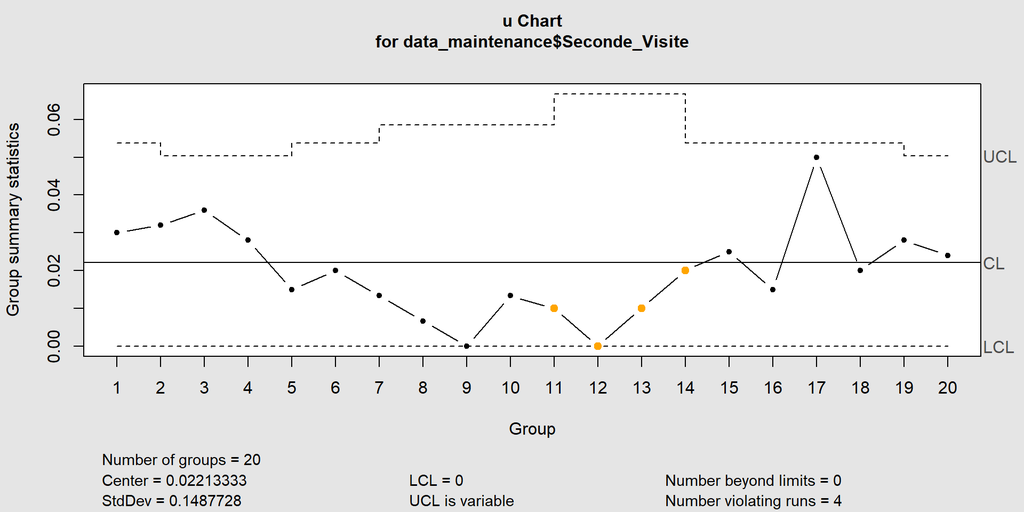

```r
# data corrigée
data_maintenance <- data.frame(
  Semaine = 1:20,
  Total_Demandes = c(200, 250, 250, 250, 200, 200, 150, 150, 150, 150,
                     100, 100, 100, 200, 200, 200, 200, 200, 250, 250),
  Seconde_Visite = c(6, 8, 9, 7, 3, 4, 2, 1, 0, 2,
                     1, 0, 1, 4, 5, 3, 10, 4, 7, 6)
)

# calcul du taux de seconde visite u
data_maintenance$Taux_Seconde_Visite <- data_maintenance$Seconde_Visite / data_maintenance$Total_Demandes

# carte u
carte_u <- qcc(
  data_maintenance$Seconde_Visite,
  sizes = data_maintenance$Total_Demandes,
  type = "u",
  plot = TRUE
)

# Affichage des statistiques de la carte
print(carte_u)
```

Bien que la carte ne signale pas d’anomalies critiques, elle met en évidence des variations dans certaines semaines, suggérant que certaines périodes ont un taux de secondes visites plus élevé. Une analyse plus approfondie permettrait d’identifier les facteurs influençant ces fluctuations, tels que la complexité des interventions, le niveau de formation des équipes, ou encore des changements organisationnels.

Pour optimiser le processus, il est recommandé de suivre les tendances sur une plus longue période et d’identifier les causes des semaines où le taux est plus élevé. Une approche combinant la carte u avec une analyse des causes racines pourrait permettre de mieux comprendre les écarts et d’améliorer durablement la qualité des interventions de maintenance.

**————————————————————————————— EXERCICE 8 ————————————————————————————–**

```r
# Paramètres de la carte p
n <- 100  # Taille de l'échantillon
p_bar <- 0.080  # Fraction moyenne de non-conformité
UCL_p <- 0.161  # Limite supérieure de la carte p
LCL_p <- 0  # Limite inférieure (ne peut être négatif)

# Conversion en carte c (nombre total de non-conformités)
c_bar <- p_bar * n  # Moyenne des non-conformités
UCL_c <- UCL_p * n  # Limite supérieure
LCL_c <- max(LCL_p * n, 0)  # Limite inférieure (doit être ≥ 0)

# Affichage des résultats de la carte c
cat("Carte c - Nombre total de non-conformités :\n")
```

```
## Carte c - Nombre total de non-conformités :
```

```r
cat("Ligne centrale :", c_bar, "\n")
```

```
## Ligne centrale : 8
```

```r
cat("Limite supérieure (UCL) :", UCL_c, "\n")
```

```
## Limite supérieure (UCL) : 16.1
```

```r
cat("Limite inférieure (LCL) :", LCL_c, "\n\n")
```

```
## Limite inférieure (LCL) : 0
```

```r
# Approximation Poisson pour calculer l'erreur de type I
lambda <- c_bar  # Poisson(λ) avec λ = moyenne attendue des non-conformités
seuil <- ceiling(UCL_c)  # Seuil critique (on prend la valeur entière supérieure)

# calcul de l'erreur de type I (P(X ≥ seuil))
erreur_type_I <- 1 - ppois(seuil - 1, lambda = lambda)

# Affichage de l'erreur de type I
cat("Approximation Poisson - Erreur de Type I :\n")
```

```
## Approximation Poisson - Erreur de Type I :
```

```r
cat("P(X ≥", seuil, ") =", round(erreur_type_I, 6), "\n")
```

```
## P(X ≥ 17 ) = 0.003718
```

La conversion de la carte p en carte c nous donne une ligne centrale de 8 non-conformités par échantillon, avec une limite supérieure de contrôle (UCL) de 16 non-conformités et une limite inférieure de 0 (ce qui est normal car un nombre de non-conformités ne peut être négatif). Cela signifie que si un échantillon dépasse 16 non-conformités, on suspectera une anomalie dans le processus.

L’erreur de type I, qui correspond à la probabilité de signaler un faux positif (détection d’un problème alors que le processus est en réalité sous contrôle), est estimée à 0.003718 en utilisant l’approximation par une loi de Poisson. Cette valeur est très faible, ce qui signifie que la carte c est très stricte : il y a moins de 0.4% de chances de détecter une fausse alerte.

En conclusion, cette carte permet un bon contrôle du processus tout en minimisant le risque de fausses alertes. Toutefois, si l’on souhaite être plus réactif aux variations, on pourrait ajuster légèrement les seuils pour mieux détecter les dérives sans être trop conservateur.